# Lecture Notes (JSV) - Multivariate analysis - 2023-02-01. Session 2

- Instituut Voor Tropische Geneeskunde - Antwerp, Belgium
- Javier Silva-Valencia

## Step by Step

##### Import data

Importing a CSV database under the name of “evans”, with “,” as separator and “.” as decimal:

```r
evans <- read.csv("C:/Users/pined/OneDrive - Universidad Nacional Mayor de San Marcos/Javier 2022/Belgica/AC2/Linear Regresion Exercise Database/Datasets/evans_county.csv", sep=",", dec= ".")
```

We assume that all variables ok to start (we dont need to transform or create variables)

### Starting the Exercise:

Is the Queteled Index(QTI) associated with systolic blood pressure(SBP)?

Independent variable: QTI

Dependent variable: SBP

##### 0. It is a good practice to explore the data. In this case with a scatterplot

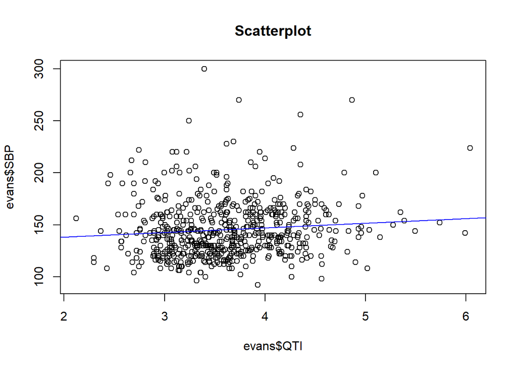

```r
#Code in R:
  # Make a scatterplot
  plot(evans$QTI, evans$SBP, main="Scatterplot")
  # add a regression line
  abline(lm(SBP~QTI, data = evans), col = "blue")
```

**Note**

-We can see that there could be a correlation, although it seen not very strong

##### 1. What is the regressión equation?

```r
#Code for linear regresion:
  lmQTI = lm(SBP ~ QTI, data = evans)
  summary(lmQTI)
```

```
Call:
lm(formula = SBP ~ QTI, data = evans)

Residuals:
    Min      1Q  Median      3Q     Max
-54.855 -19.634  -5.213  14.743 155.497

Coefficients:
            Estimate Std. Error t value Pr(>|t|)
(Intercept)  129.420      6.875  18.824   <2e-16 ***
QTI            4.439      1.876   2.366   0.0183 *
---
Signif. codes:  0 '***' 0.001 '**' 0.01 '*' 0.05 '.' 0.1 ' ' 1

Residual standard error: 27.4 on 607 degrees of freedom
Multiple R-squared:  0.00914,   Adjusted R-squared:  0.007508
F-statistic: 5.599 on 1 and 607 DF,  p-value: 0.01828
```

**Note**

-As a result: we can create the equation with the data we obtained

```
* Formula:  y = a+b(x)
* a = 129.420
* b = 4.439
    (b is the slope,
    it means that for every increase of 1 in QTI the SBP increase in 4.43)

So, the equation would be:
* Y= 129.420 + 4.439(X)
```

##### 2. How much is the determination coefficient? What does it mean?

**Note**

-The determination coefficient is R2 = 0.009

```
Interpretation:
" __%  of the variability of the outcome could be explained by the model "
"0.9% of the variability of the SBP(blood preasure) could be explained by the model"
```

##### 3. Is the slope for QTI statiscally significant?

**Note**

-The slope for QTI is 4.439 -And its p value is 0.0183 (less than 0.05)

```
Interpretation:
*P value in this case says that there is a statisticas association (that is the same that       says that "the slope of the regresion line is significanly different from zero)
```

### Testing the assumptions (linearity, homogeneity of variance, normality…)

First we need to calculate the residuals an calculate the estimated outcome(fitted) as new variables

```r
evans$mod_resid <- residuals(lmQTI)
evans$mod_fitted <- fitted(lmQTI)
```

##### 4. Is the association betwenn SBP and QTI a linear association?

We scatterplot the residuals against the exposure(VI)

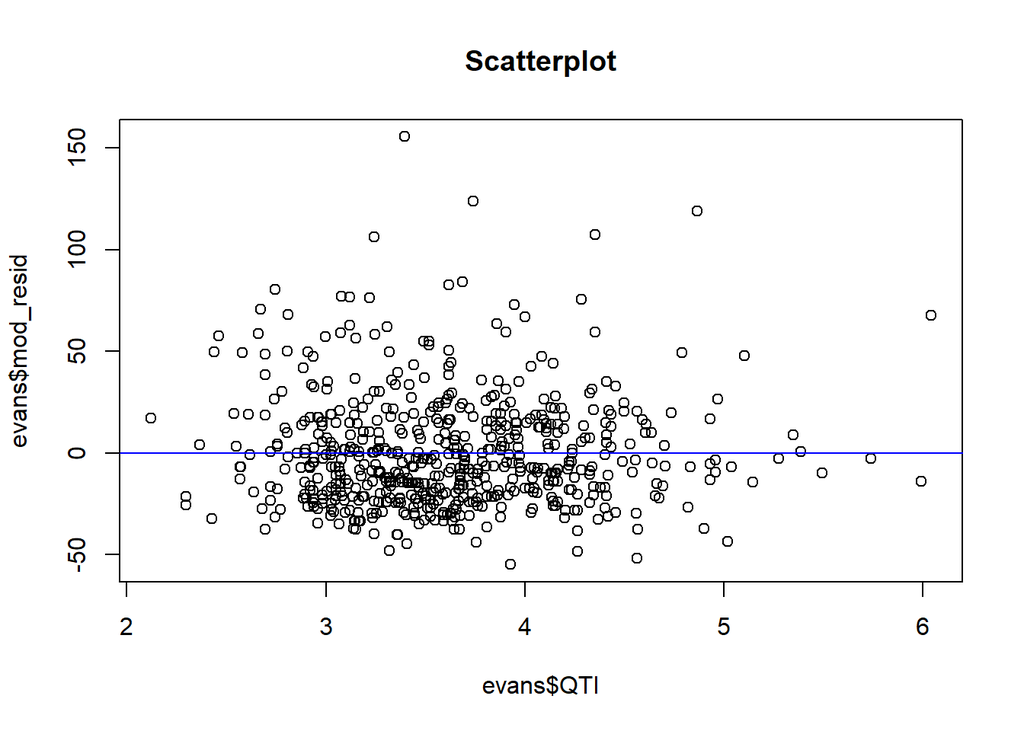

```r
#Code in R:
  # Make a scatterplot
  plot(evans$QTI, evans$mod_resid, main="Scatterplot")
  # add a regression line
  abline(lm(mod_resid~QTI, data = evans), col = "blue")
```

**Note**

```
We scatterplot the residuals against the exposure(VI)
In this case because we see it as a cloud, then we assume linearity
```

##### 5. Is the variance of the residuals homogeneous?

We scatterplot the residuals against the estimated outcome(fitted)

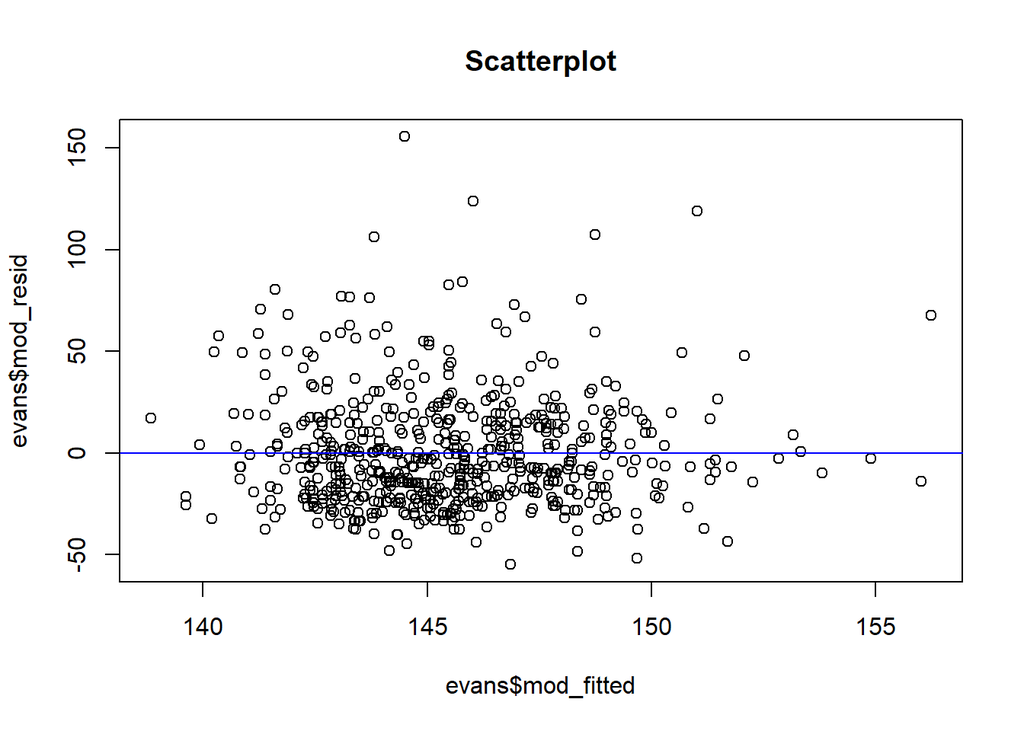

```r
#Code in R:
  # Make a scatterplot
  plot(evans$mod_fitted, evans$mod_resid, main="Scatterplot")
  # add a regression line
  abline(lm(mod_resid ~ mod_fitted, data = evans), col = "blue")
```

**Note**

```
We residuals against the estimated outcome(fitted)
In this case because we see it as a cloud, then we assume homogeneity
```

##### 6. Are the residuals normally distributted?

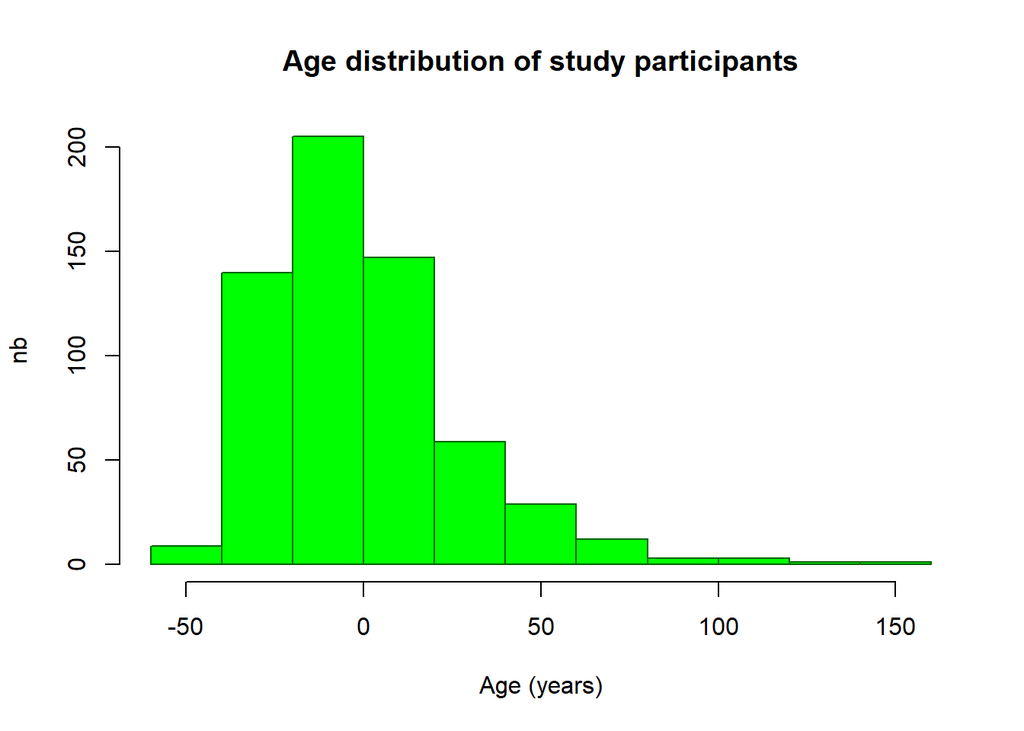

```r
#Doing an histogram of the residuals
  hist(evans$mod_resid,main="Age distribution of study participants",
     xlab="Age (years)", ylab="nb", col="green", border="dark green")
```

**Note**

```
Seems not
```

##### 7. Are the observations independent?

**Note**

```
We dont need any calculation for this.
Because we are not working with sequential measures (in time or in space):
  The observations  are  independent
```

##### 8. Are there any extreme values?

**Note**

```
For this we need to made a scatter plot of the residuals against the estimated outcome (fitted) (we already did this in step 5 )

For discussion. It seems to have some extreme values.
```

##### 9. Are there any influential observation?

**Note**

```
For this we need to made a scatter plot of the residuals against the exposure (we already did this in step 4 )

For discussion. It seems to have some influential observations.
```

##### 10. Does the model significantly improve when the variable AGE is added?

We do this doing an multivariate linear regresion

```r
#Code for linear regresion:
  lmQTI_AGE = lm(SBP ~ QTI+AGE, data = evans)
  summary(lmQTI_AGE)
```

```
Call:
lm(formula = SBP ~ QTI + AGE, data = evans)

Residuals:
    Min      1Q  Median      3Q     Max
-57.645 -15.916  -3.985  11.393 160.285

Coefficients:
            Estimate Std. Error t value Pr(>|t|)
(Intercept)  73.4912     9.2816   7.918 1.16e-14 ***
QTI           5.6031     1.7809   3.146  0.00173 **
AGE           0.9630     0.1139   8.452  < 2e-16 ***
---
Signif. codes:  0 '***' 0.001 '**' 0.01 '*' 0.05 '.' 0.1 ' ' 1

Residual standard error: 25.93 on 606 degrees of freedom
Multiple R-squared:  0.1136,    Adjusted R-squared:  0.1107
F-statistic: 38.84 on 2 and 606 DF,  p-value: < 2.2e-16
```

**Note**

-A. As a result: we can create the new formula with the data we obtained

```
* y = a + b1(x1) + b2(x2)
* a= 73.4912
* b1 = 5.6031
* b2 = 0.9630
So, the formula would be:
* Y= 73.4912 + 5.6031(QTI) + 0.9630(AGE)
```

-B. We also find the R2

```
* R2 is the "Determination coefficient".
* R2 =  0.1136
Interpretation:
"11% of the variability of the SBP could be explained by the model"
```

-C. Does the model significantly improve when the variable AGE is added?

```
* It improves, but I dont know if it is a significantly improvement.
```

To know if it is a significantly improvement, we can do an anova table comparing the 2 models

```r
#Code for ANOVA
    anova (lmQTI,lmQTI_AGE)
```

```
Analysis of Variance Table

Model 1: SBP ~ QTI
Model 2: SBP ~ QTI + AGE
  Res.Df    RSS Df Sum of Sq      F    Pr(>F)
1    607 455567
2    606 407530  1     48037 71.432 < 2.2e-16 ***
---
Signif. codes:  0 '***' 0.001 '**' 0.01 '*' 0.05 '.' 0.1 ' ' 1
```

**Note**

p = 2.2e-16 The second model has a significant difference to the first model, so including AGE has increased significantly the model.

##### 11. Which proportion of the variability in SBP is explained by this model?

**Note**

We already did it at step 10 * R2 is the “Determination coefficient”. * R2 = 0.1136 Interpretation: “11% of the variability of the SBP could be explained by the model”

##### 12. Please write down the equation of the model

**Note**

We already did it at step 10 * y = a + b1(x1) + b2(x2) * a= 73.4912 * b1 = 5.6031 * b2 = 0.9630 So, the formula would be: * Y= 73.4912 + 5.6031(QTI) + 0.9630(AGE)

Finish =)